# Preparations

## Variable names and descriptions

| Variable name | Description |
| --- | --- |
| `eonia` | Eonia |
| `eonia_to` | Eonia with €STR methodology + 8.5 bp |
| `estr` | Euro short-term rate, €STR |
| `ipi_nsa` | Industrial Production Index (2015 = 100) NSA |
| `defl_nsa` | GDP deflator (2015 = 100) NSA |
| `time` | Time trend |

## Annual inflation

### GDP deflator seasonal adjustment

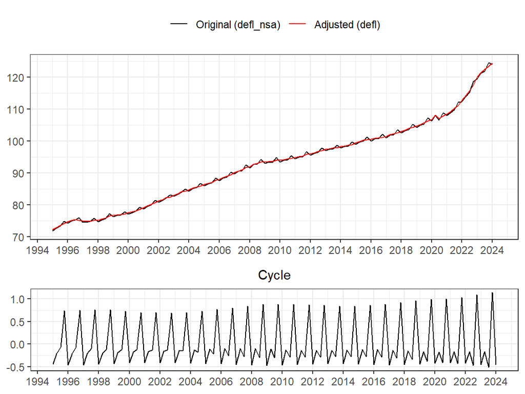

### Seasonally adjusted GDP deflator percent change

Taking the percentage change of `defl`, we obtain the annual inflation rate created from the GDP deflator, `inf`.

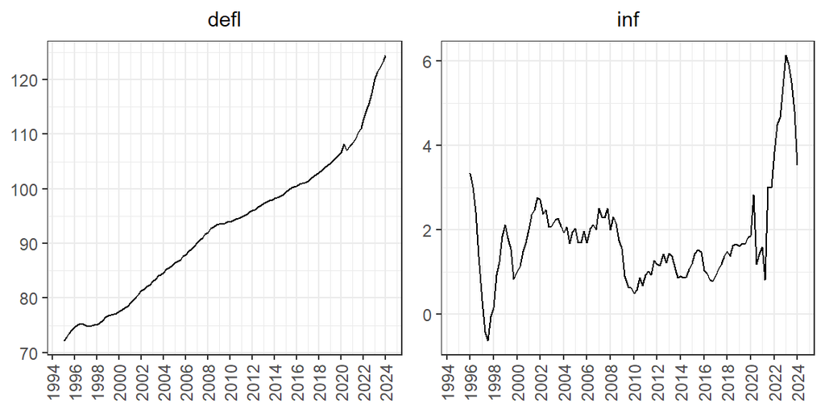

## Output gap

### Industrial Production Index seasonal adjustment

Adjusting the Industrial Production Index `ipi_nsa` via X-13ARIMA-SEATS, we obtain the seasonally adjusted Industrial Production Index `ipi`.

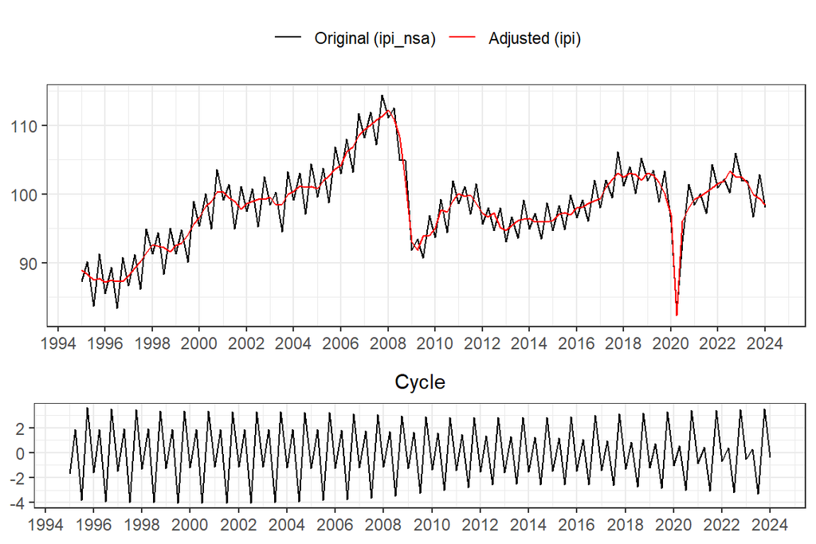

### Seasonally adjusted Industrial Production Index Hodrick-Prescott filter

The creation of the output gap using the Industrial Production Index is done via obtaining the cyclical component of a Hodrick-Prescott filter with $\lambda = 1600$ on the seasonally adjusted Industrial Production Index `ipi`. The cyclical component obtained is multiplied by 100 on order to obtain the output gap `ogap`.

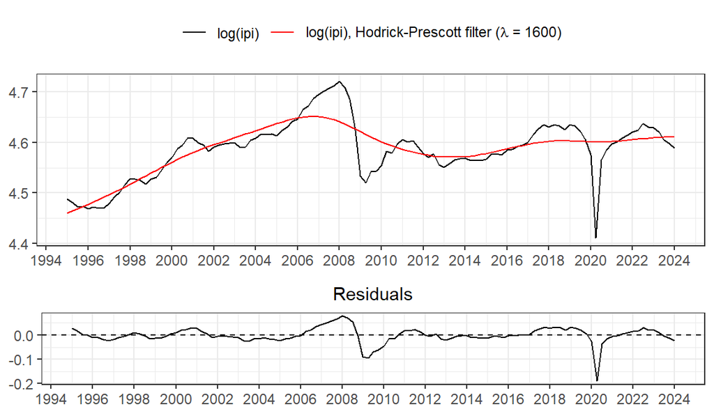

## Interest rate

In 2019, the European Central Bank (ECB), made the decision of deprecate the EONIA rate in favor of the euro short term rate (€STR).

In order to achieve an smooth transition from the EONIA to the €STR, the ECB released an EONIA computed with a new methodology that consist of the €STR plus a fixed spread of 8.5 basis points until January 3rd 2022. The EONIA with the original methodology was discontinued October 2nd 2019.

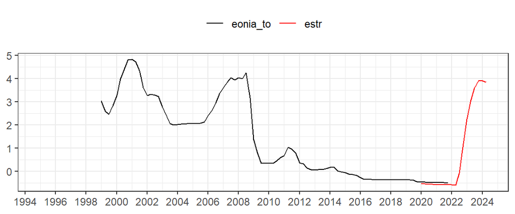

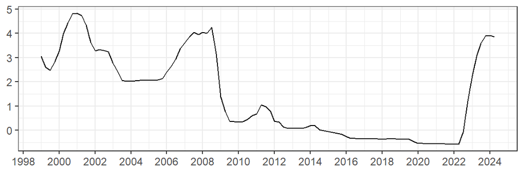